# Linear Regression

Helen Yezerets

February 19, 2019

```r
#install.packages("devtools")
#devtools::install_github("nickpoison/astsa")
library(devtools)
library(astsa)
```

```r
data("chicken")
summary(fit <- lm(chicken~time(chicken), na.action=NULL))
```

```
##
## Call:
## lm(formula = chicken ~ time(chicken), na.action = NULL)
##
## Residuals:
##     Min      1Q  Median      3Q     Max
## -8.7411 -3.4730  0.8251  2.7738 11.5804
##
## Coefficients:
##                 Estimate Std. Error t value Pr(>|t|)
## (Intercept)   -7.131e+03  1.624e+02  -43.91   <2e-16 ***
## time(chicken)  3.592e+00  8.084e-02   44.43   <2e-16 ***
## ---
## Signif. codes:  0 '***' 0.001 '**' 0.01 '*' 0.05 '.' 0.1 ' ' 1
##
## Residual standard error: 4.696 on 178 degrees of freedom
## Multiple R-squared:  0.9173, Adjusted R-squared:  0.9168
## F-statistic:  1974 on 1 and 178 DF,  p-value: < 2.2e-16
```

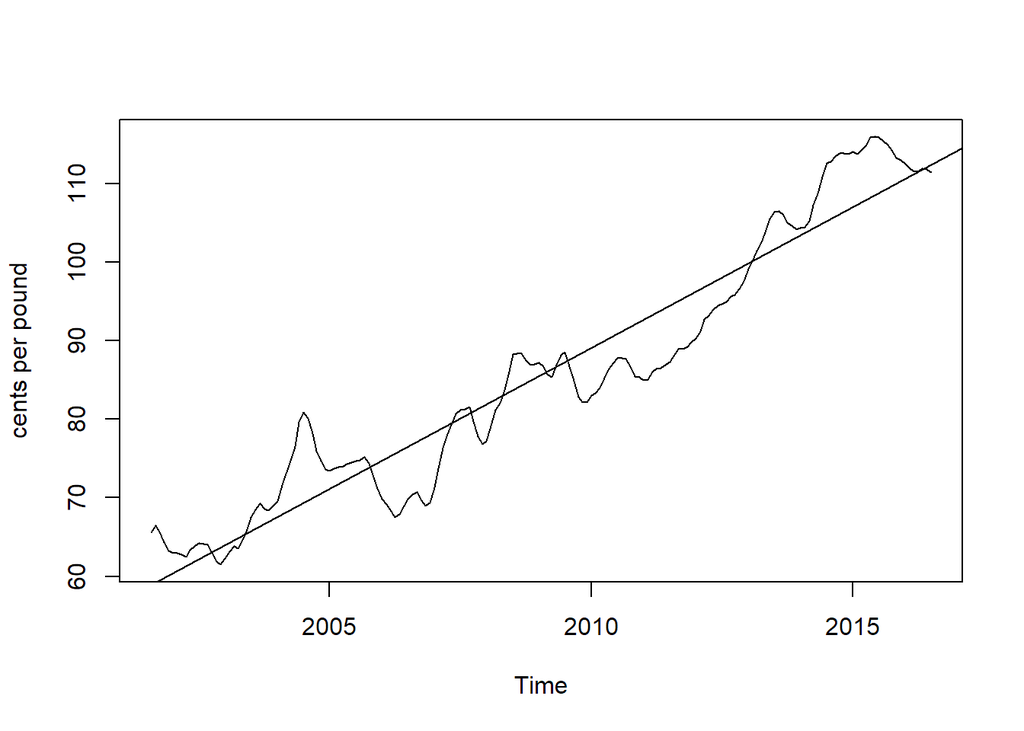

```r
plot(chicken, ylab="cents per pound")
abline(fit) # add the fitted line
```

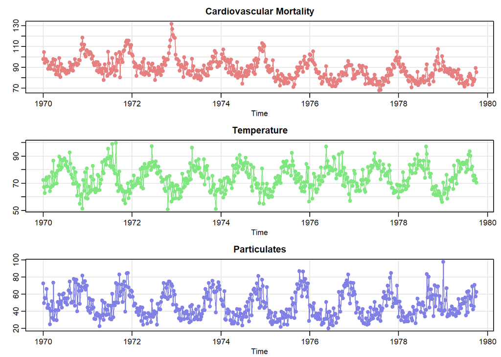

```r
culer = c(rgb(.9,.5,.5), rgb(.5,.9,.5), rgb(.5,.5,.9))
par(mfrow=c(3,1))
tsplot(cmort, main="Cardiovascular Mortality", col=culer[1], type="o", pch=19, ylab="")
tsplot(tempr, main="Temperature", col=culer[2], type="o", pch=19, ylab="")
tsplot(part, main="Particulates", col=culer[3], type="o", pch=19, ylab="")
```

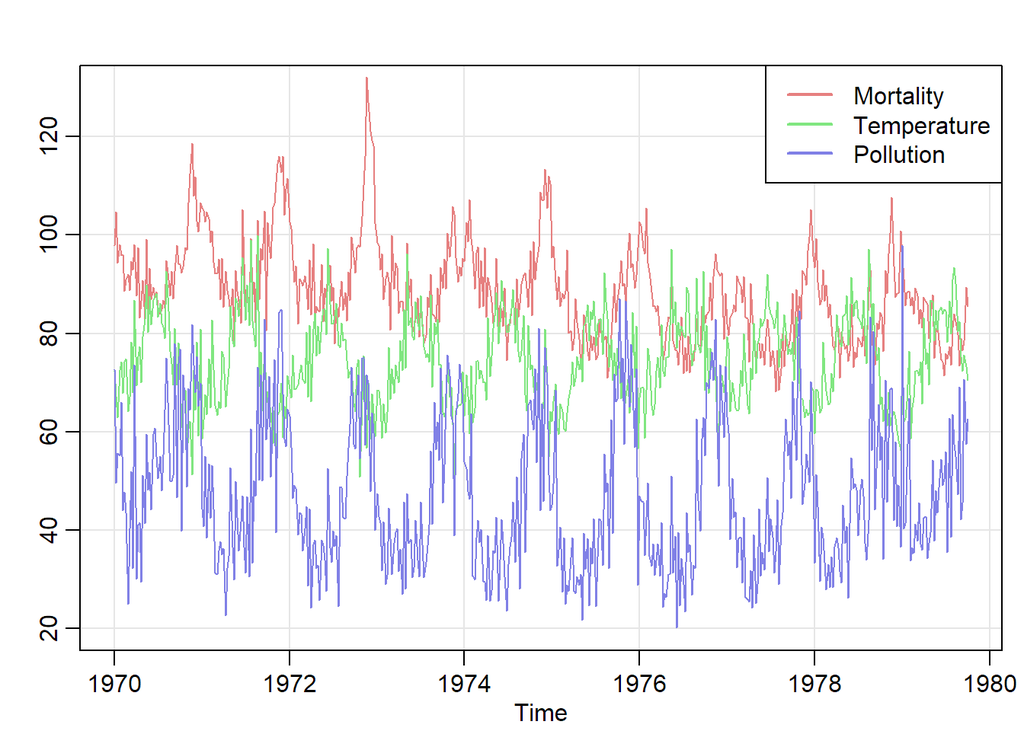

```r
tsplot(cmort, main="", ylab="", ylim=c(20,130), col=culer[1])
lines(tempr, col=culer[2])
lines(part, col=culer[3])
legend("topright", legend=c("Mortality", "Temperature", "Pollution"), lty=1, lwd=2, col=culer, bg="white")
```

```r
##
```

```r
dev.new() # open a new graphic device
ts.plot(cmort,tempr,part, col=1:3) # all on same plot (not shown)
```

## Load dynlm

```r
fish = ts.intersect(rec, soiL6=lag(soi,-6), dframe=TRUE)
summary(fit1 <- lm(rec~soiL6, data=fish, na.action=NULL))
```

```
##
## Call:
## lm(formula = rec ~ soiL6, data = fish, na.action = NULL)
##
## Residuals:
##     Min      1Q  Median      3Q     Max
## -65.187 -18.234   0.354  16.580  55.790
##
## Coefficients:
##             Estimate Std. Error t value Pr(>|t|)
## (Intercept)   65.790      1.088   60.47   <2e-16 ***
## soiL6        -44.283      2.781  -15.92   <2e-16 ***
## ---
## Signif. codes:  0 '***' 0.001 '**' 0.01 '*' 0.05 '.' 0.1 ' ' 1
##
## Residual standard error: 22.5 on 445 degrees of freedom
## Multiple R-squared:  0.3629, Adjusted R-squared:  0.3615
## F-statistic: 253.5 on 1 and 445 DF,  p-value: < 2.2e-16
```

```r
#The headache of aligning the lagged series can be avoided by using the R package
#dynlm, which must be downloaded and installed.
library(dynlm)
summary(fit2 <- dynlm(rec~ L(soi,6)))
```

```
##
## Time series regression with "ts" data:
## Start = 1950(7), End = 1987(9)
##
## Call:
## dynlm(formula = rec ~ L(soi, 6))
##
## Residuals:
##     Min      1Q  Median      3Q     Max
## -65.187 -18.234   0.354  16.580  55.790
##
## Coefficients:
##             Estimate Std. Error t value Pr(>|t|)
## (Intercept)   65.790      1.088   60.47   <2e-16 ***
## L(soi, 6)    -44.283      2.781  -15.92   <2e-16 ***
## ---
## Signif. codes:  0 '***' 0.001 '**' 0.01 '*' 0.05 '.' 0.1 ' ' 1
##
## Residual standard error: 22.5 on 445 degrees of freedom
## Multiple R-squared:  0.3629, Adjusted R-squared:  0.3615
## F-statistic: 253.5 on 1 and 445 DF,  p-value: < 2.2e-16
```

## 2.

Reproduce the same workflow for unemp data (from astsa package)

```r
data("unemp")
summary(fit <- lm(unemp~time(unemp), na.action=NULL))
```

```
##
## Call:
## lm(formula = unemp ~ time(unemp), na.action = NULL)
##
## Residuals:
##     Min      1Q  Median      3Q     Max
## -234.32  -72.71  -10.25   63.84  318.77
##
## Coefficients:
##               Estimate Std. Error t value Pr(>|t|)
## (Intercept) -2.343e+04  1.259e+03  -18.61   <2e-16 ***
## time(unemp)  1.213e+01  6.413e-01   18.92   <2e-16 ***
## ---
## Signif. codes:  0 '***' 0.001 '**' 0.01 '*' 0.05 '.' 0.1 ' ' 1
##
## Residual standard error: 110.7 on 370 degrees of freedom
## Multiple R-squared:  0.4917, Adjusted R-squared:  0.4903
## F-statistic: 357.9 on 1 and 370 DF,  p-value: < 2.2e-16
```

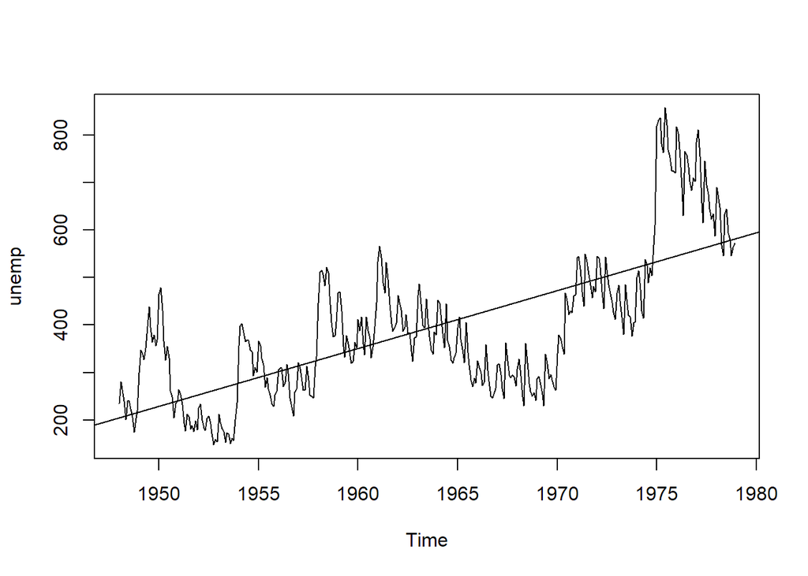

```r
plot(unemp)
abline(fit) # add the fitted line
```

## 3.

Follow steps from the example 2.2. Review stats in the chapter as needed. * from summary(fit) obtain the results for R-squared and df * from summary(aov(fit)) obtain MSE * from AIC and BIC formula obtain AIC and BIC

Compare your results with the table 2.2 page 53.

## 4.

Reduce the model by removing one independent variable, starting from the last one:

cmort~ trend + temp + temp2 + part becomes cmort~ trend + temp + temp2

Obtain the summary stats and compare with the table 2.2

```r
dev.new()
pairs(cbind(Mortality=cmort, Temperature=tempr, Particulates=part))
temp = tempr-mean(tempr) # center temperature
temp2 = temp^2
trend = time(cmort) # time
fit21 = lm(cmort~ trend + temp + temp2 + part, na.action=NULL)

fit20 = lm(cmort~ trend + temp + temp2, na.action=NULL)

fit19 = lm(cmort~ trend + temp, na.action=NULL)
```

```r
summary(fit21) # regression results
```

```
##
## Call:
## lm(formula = cmort ~ trend + temp + temp2 + part, na.action = NULL)
##
## Residuals:
##      Min       1Q   Median       3Q      Max
## -19.0760  -4.2153  -0.4878   3.7435  29.2448
##
## Coefficients:
##               Estimate Std. Error t value Pr(>|t|)
## (Intercept)  2.831e+03  1.996e+02   14.19  < 2e-16 ***
## trend       -1.396e+00  1.010e-01  -13.82  < 2e-16 ***
## temp        -4.725e-01  3.162e-02  -14.94  < 2e-16 ***
## temp2        2.259e-02  2.827e-03    7.99 9.26e-15 ***
## part         2.554e-01  1.886e-02   13.54  < 2e-16 ***
## ---
## Signif. codes:  0 '***' 0.001 '**' 0.01 '*' 0.05 '.' 0.1 ' ' 1
##
## Residual standard error: 6.385 on 503 degrees of freedom
## Multiple R-squared:  0.5954, Adjusted R-squared:  0.5922
## F-statistic:   185 on 4 and 503 DF,  p-value: < 2.2e-16
```

```r
#R2=Multiple R-squared:  0.5954,    Adjusted R-squared:  0.5922
summary(fit20)
```

```
##
## Call:
## lm(formula = cmort ~ trend + temp + temp2, na.action = NULL)
##
## Residuals:
##     Min      1Q  Median      3Q     Max
## -17.464  -4.858  -0.945   4.511  34.939
##
## Coefficients:
##               Estimate Std. Error t value Pr(>|t|)
## (Intercept)  3.038e+03  2.322e+02  13.083  < 2e-16 ***
## trend       -1.494e+00  1.176e-01 -12.710  < 2e-16 ***
## temp        -4.808e-01  3.689e-02 -13.031  < 2e-16 ***
## temp2        2.583e-02  3.287e-03   7.858 2.38e-14 ***
## ---
## Signif. codes:  0 '***' 0.001 '**' 0.01 '*' 0.05 '.' 0.1 ' ' 1
##
## Residual standard error: 7.452 on 504 degrees of freedom
## Multiple R-squared:  0.4479, Adjusted R-squared:  0.4446
## F-statistic: 136.3 on 3 and 504 DF,  p-value: < 2.2e-16
```

```r
summary(fit19)
```

```
##
## Call:
## lm(formula = cmort ~ trend + temp, na.action = NULL)
##
## Residuals:
##     Min      1Q  Median      3Q     Max
## -16.846  -5.330  -1.207   4.701  33.306
##
## Coefficients:
##               Estimate Std. Error t value Pr(>|t|)
## (Intercept) 3125.75988  245.48233   12.73   <2e-16 ***
## trend         -1.53785    0.12430  -12.37   <2e-16 ***
## temp          -0.45792    0.03893  -11.76   <2e-16 ***
## ---
## Signif. codes:  0 '***' 0.001 '**' 0.01 '*' 0.05 '.' 0.1 ' ' 1
##
## Residual standard error: 7.887 on 505 degrees of freedom
## Multiple R-squared:  0.3802, Adjusted R-squared:  0.3778
## F-statistic: 154.9 on 2 and 505 DF,  p-value: < 2.2e-16
```

```r
#Residuals: df, SSE=Sum Sq, MSE=Mean Sq
summary(aov(fit21)) # ANOVA table (compare to next line)
```

```
##              Df Sum Sq Mean Sq F value Pr(>F)
## trend         1  10667   10667  261.62 <2e-16 ***
## temp          1   8607    8607  211.09 <2e-16 ***
## temp2         1   3429    3429   84.09 <2e-16 ***
## part          1   7476    7476  183.36 <2e-16 ***
## Residuals   503  20508      41
## ---
## Signif. codes:  0 '***' 0.001 '**' 0.01 '*' 0.05 '.' 0.1 ' ' 1
```

```r
#Residuals: df, SSE=Sum Sq, MSE=Mean Sq
summary(aov(lm(cmort~cbind(trend, temp, temp2, part)))) # Table 2.1
```

```
##                                  Df Sum Sq Mean Sq F value Pr(>F)
## cbind(trend, temp, temp2, part)   4  30178    7545     185 <2e-16 ***
## Residuals                       503  20508      41
## ---
## Signif. codes:  0 '***' 0.001 '**' 0.01 '*' 0.05 '.' 0.1 ' ' 1
```

```r
#Residuals: df, SSE=Sum Sq, MSE=Mean Sq
summary(aov(fit20)) # ANOVA table (compare to next line)
```

```
##              Df Sum Sq Mean Sq F value   Pr(>F)
## trend         1  10667   10667  192.11  < 2e-16 ***
## temp          1   8607    8607  155.00  < 2e-16 ***
## temp2         1   3429    3429   61.75 2.38e-14 ***
## Residuals   504  27985      56
## ---
## Signif. codes:  0 '***' 0.001 '**' 0.01 '*' 0.05 '.' 0.1 ' ' 1
```

```r
#Residuals: df, SSE=Sum Sq, MSE=Mean Sq
summary(aov(lm(cmort~cbind(trend, temp, temp2)))) # Table 2.1
```

```
##                            Df Sum Sq Mean Sq F value Pr(>F)
## cbind(trend, temp, temp2)   3  22702    7567   136.3 <2e-16 ***
## Residuals                 504  27985      56
## ---
## Signif. codes:  0 '***' 0.001 '**' 0.01 '*' 0.05 '.' 0.1 ' ' 1
```

```r
#Residuals: df, SSE=Sum Sq, MSE=Mean Sq
summary(aov(fit19)) # ANOVA table (compare to next line)
```

```
##              Df Sum Sq Mean Sq F value Pr(>F)
## trend         1  10667   10667   171.5 <2e-16 ***
## temp          1   8607    8607   138.4 <2e-16 ***
## Residuals   505  31413      62
## ---
## Signif. codes:  0 '***' 0.001 '**' 0.01 '*' 0.05 '.' 0.1 ' ' 1
```

```r
#Residuals: df, SSE=Sum Sq, MSE=Mean Sq
summary(aov(lm(cmort~cbind(trend, temp)))) # Table 2.1
```

```
##                     Df Sum Sq Mean Sq F value Pr(>F)
## cbind(trend, temp)   2  19273    9637   154.9 <2e-16 ***
## Residuals          505  31413      62
## ---
## Signif. codes:  0 '***' 0.001 '**' 0.01 '*' 0.05 '.' 0.1 ' ' 1
```

```r
num = length(cmort) # sample size

#21
AIC(fit21)/num - log(2*pi) # AIC
```

```
## [1] 4.721732
```

```r
BIC(fit21)/num - log(2*pi) # BIC
```

```
## [1] 4.771699
```

```r
(AICc = log(sum(resid(fit21)^2)/num) + (num+5)/(num-5-2)) # AICc
```

```
## [1] 4.722062
```

```r
#20
AIC(fit20)/num - log(2*pi) # AIC
```

```
## [1] 5.028611
```

```r
BIC(fit20)/num - log(2*pi) # BIC
```

```
## [1] 5.070249
```

```r
(AICc = log(sum(resid(fit20)^2)/num) + (num+5)/(num-5-2)) # AICc
```

```
## [1] 5.032878
```

```r
#19
AIC(fit19)/num - log(2*pi) # AIC
```

```
## [1] 5.14025
```

```r
BIC(fit19)/num - log(2*pi) # BIC
```

```
## [1] 5.173561
```

```r
(AICc = log(sum(resid(fit19)^2)/num) + (num+5)/(num-5-2)) # AICc
```

```
## [1] 5.148454
```

## 5.

Your last model should be cmort~trend

```r
fit18 = lm(cmort~ trend, na.action=NULL)
summary(fit18)
```

```
##
## Call:
## lm(formula = cmort ~ trend, na.action = NULL)
##
## Residuals:
##     Min      1Q  Median      3Q     Max
## -16.445  -6.670  -1.366   5.505  40.107
##
## Coefficients:
##              Estimate Std. Error t value Pr(>|t|)
## (Intercept) 3297.6062   276.3132   11.93   <2e-16 ***
## trend         -1.6249     0.1399  -11.61   <2e-16 ***
## ---
## Signif. codes:  0 '***' 0.001 '**' 0.01 '*' 0.05 '.' 0.1 ' ' 1
##
## Residual standard error: 8.893 on 506 degrees of freedom
## Multiple R-squared:  0.2104, Adjusted R-squared:  0.2089
## F-statistic: 134.9 on 1 and 506 DF,  p-value: < 2.2e-16
```

# Residuals: df, SSE=Sum Sq, MSE=Mean Sq

```r
summary(aov(fit18)) # ANOVA table (compare to next line)
```

```
##              Df Sum Sq Mean Sq F value Pr(>F)
## trend         1  10667   10667   134.9 <2e-16 ***
## Residuals   506  40020      79
## ---
## Signif. codes:  0 '***' 0.001 '**' 0.01 '*' 0.05 '.' 0.1 ' ' 1
```

```r
#Residuals: df, SSE=Sum Sq, MSE=Mean Sq
summary(aov(lm(cmort~cbind(trend)))) # Table 2.1
```

```
##               Df Sum Sq Mean Sq F value Pr(>F)
## cbind(trend)   1  10667   10667   134.9 <2e-16 ***
## Residuals    506  40020      79
## ---
## Signif. codes:  0 '***' 0.001 '**' 0.01 '*' 0.05 '.' 0.1 ' ' 1
```

```r
#18
AIC(fit18)/num - log(2*pi) # AIC
```

```
## [1] 5.37846
```

```r
BIC(fit18)/num - log(2*pi) # BIC
```

```
## [1] 5.403443
```

```r
(AICc = log(sum(resid(fit18)^2)/num) + (num+5)/(num-5-2)) # AICc
```

```
## [1] 5.390601
```

## 6

Load econ5 data

```r
data(econ5, package="astsa")
```

## 7.

Plot unemployment, gnp, consumption. Hint: you can extract each column with $. The following columns exist: unemp, gnp, consum, govinv, prinv.

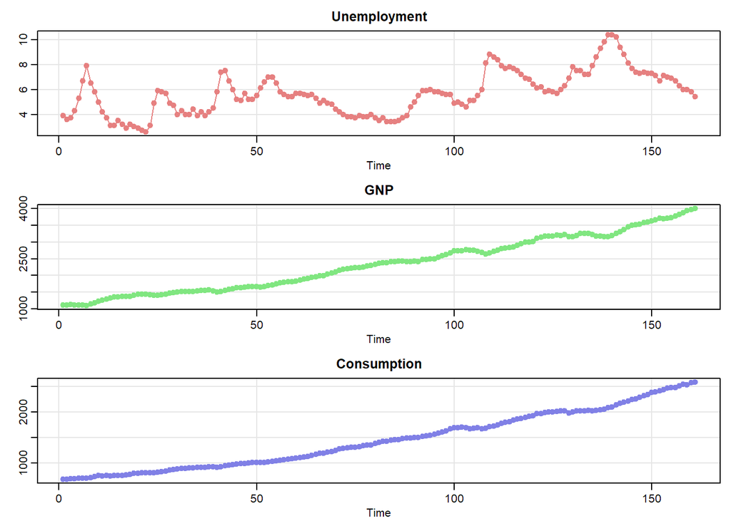

```r
par(mfrow=c(3,1))
tsplot(econ5$unemp, main="Unemployment",  col=culer[1],type="o",pch=19, ylab="")
tsplot(econ5$gnp, main="GNP", col=culer[2], type="o", pch=19, ylab="")
tsplot(econ5$consum, main="Consumption", col=culer[3], type="o", pch=19, ylab="")
```

##8. Create **pairs** with all three columns. Hint: you can extract each column with $

```r
dev.new()
pairs(cbind(Unemployment=econ5$unemp, GNP=econ5$gnp, Consumption=econ5$consum))
```

## 9.

econ5 is a dataframe. Convert it into a time series using ts function. Set start=c(1948, 3), end=c(1988, 2), frequency=4 - review econ5 information to understand why we are using frequency 4 (by quarter)

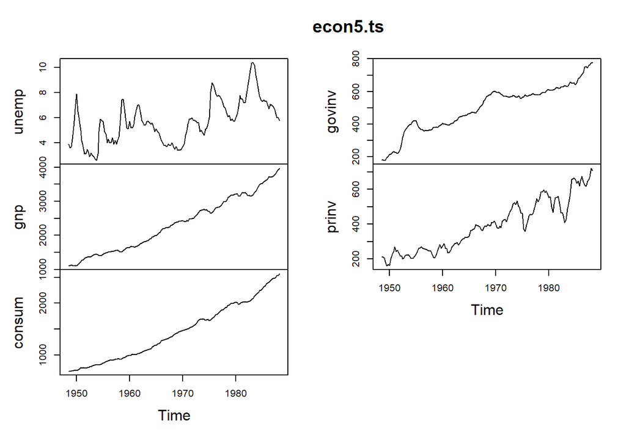

```r
econ5.ts <- ts(econ5, start=c(1948,3), end=c(1988,2), frequency = 4)
plot(econ5.ts)
```

## 10.

Create four variables for lm(). In the example below replace usdata with the name of your time series.

```r
trend = time(econ5.ts) #time
gnp <- econ5.ts[,2]
consum <- econ5.ts[,3]
response <- econ5.ts[,1]
```

## 11.

Create a model **lm()** with y=response and x1=trend, x2=gnp, x3=consum (independent variables). See step 4 above.

```r
fit_econ1 <- lm(response~ trend + gnp + consum, na.action=NULL)
fit_econ2 <- lm(response~ trend + gnp, na.action=NULL)
fit_econ3 <- lm(response~ trend, na.action=NULL)
```

## 12

Obtain a summary of your model

```r
summary(fit_econ1)
```

```
##
## Call:
## lm(formula = response ~ trend + gnp + consum, na.action = NULL)
##
## Residuals:
##      Min       1Q   Median       3Q      Max
## -1.98723 -0.45099 -0.04671  0.46611  2.13823
##
## Coefficients:
##               Estimate Std. Error t value Pr(>|t|)
## (Intercept) -1.073e+03  8.120e+01  -13.22   <2e-16 ***
## trend        5.578e-01  4.196e-02   13.29   <2e-16 ***
## gnp         -2.282e-02  1.244e-03  -18.35   <2e-16 ***
## consum       2.363e-02  1.577e-03   14.98   <2e-16 ***
## ---
## Signif. codes:  0 '***' 0.001 '**' 0.01 '*' 0.05 '.' 0.1 ' ' 1
##
## Residual standard error: 0.7554 on 156 degrees of freedom
## Multiple R-squared:  0.8089, Adjusted R-squared:  0.8053
## F-statistic: 220.1 on 3 and 156 DF,  p-value: < 2.2e-16
```

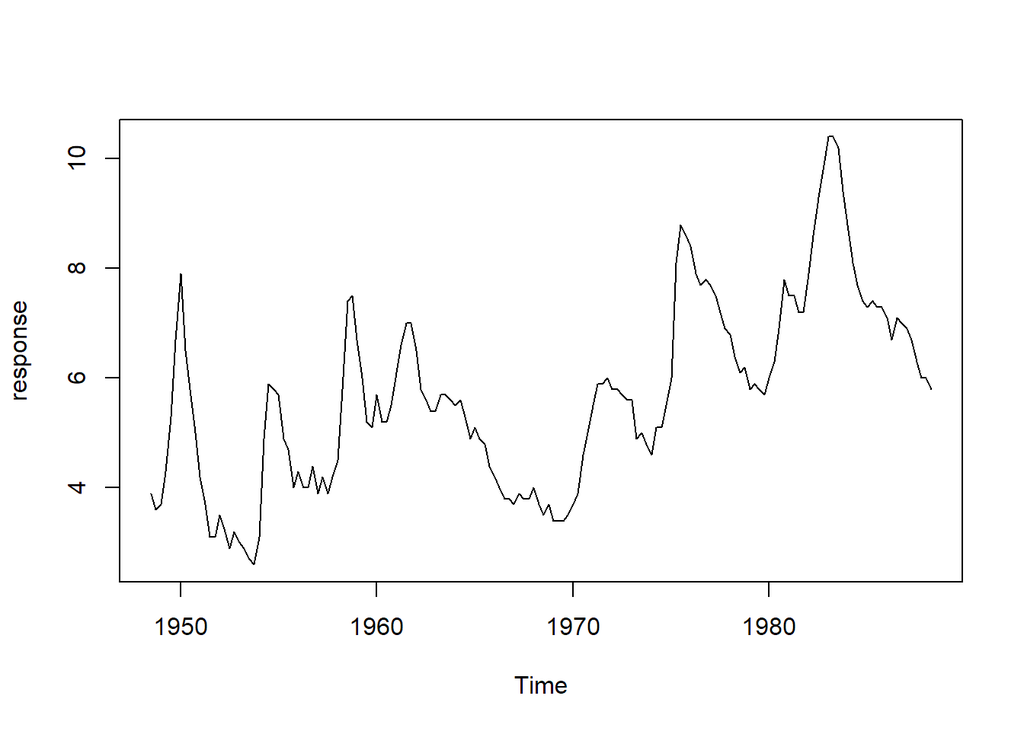

```r
plot(response)
abline(fit_econ1) # add the fitted line
```

```r
summary(fit_econ2)
```

```
##
## Call:
## lm(formula = response ~ trend + gnp, na.action = NULL)
##
## Residuals:
##     Min      1Q  Median      3Q     Max
## -2.3030 -0.7265 -0.0493  0.7121  4.1819
##
## Coefficients:
##               Estimate Std. Error t value Pr(>|t|)
## (Intercept) -1.047e+03  1.264e+02  -8.283 4.96e-14 ***
## trend        5.424e-01  6.531e-02   8.305 4.35e-14 ***
## gnp         -6.527e-03  9.399e-04  -6.944 9.51e-11 ***
## ---
## Signif. codes:  0 '***' 0.001 '**' 0.01 '*' 0.05 '.' 0.1 ' ' 1
##
## Residual standard error: 1.176 on 157 degrees of freedom
## Multiple R-squared:  0.5339, Adjusted R-squared:  0.528
## F-statistic: 89.92 on 2 and 157 DF,  p-value: < 2.2e-16
```

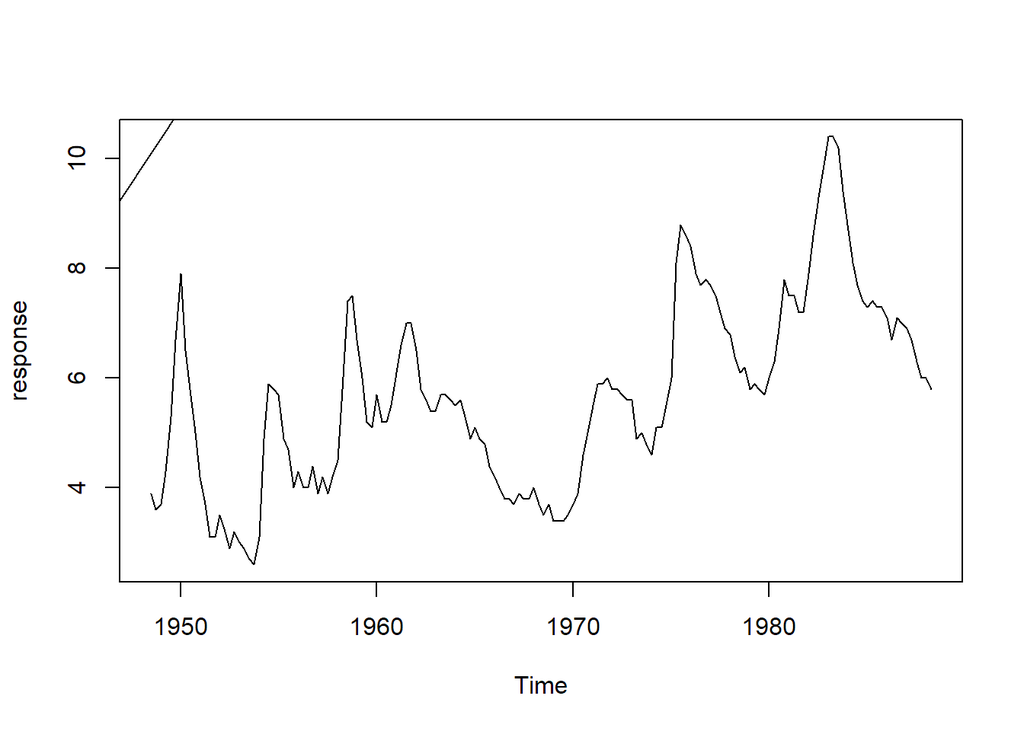

```r
plot(response)
abline(fit_econ2) # add the fitted line
```

```r
summary(fit_econ3)
```

```
##
## Call:
## lm(formula = response ~ trend, na.action = NULL)
##
## Residuals:
##     Min      1Q  Median      3Q     Max
## -2.3889 -1.0031 -0.2042  0.7078  3.9124
##
## Coefficients:
##               Estimate Std. Error t value Pr(>|t|)
## (Intercept) -1.761e+02  1.806e+01  -9.751   <2e-16 ***
## trend        9.238e-02  9.177e-03  10.066   <2e-16 ***
## ---
## Signif. codes:  0 '***' 0.001 '**' 0.01 '*' 0.05 '.' 0.1 ' ' 1
##
## Residual standard error: 1.34 on 158 degrees of freedom
## Multiple R-squared:  0.3907, Adjusted R-squared:  0.3869
## F-statistic: 101.3 on 1 and 158 DF,  p-value: < 2.2e-16
```

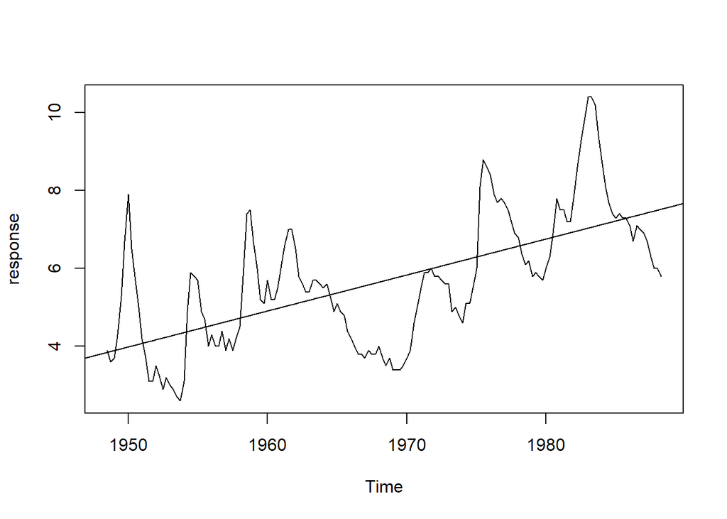

```r
plot(response)
abline(fit_econ3) # add the fitted line
```